# Project: Analysis of loan Data from Prosper

## By Roy Muchiri

- Introduction
- Preliminary Wrangling
- Exploratory Data Analysis
- Conclusions

## Introduction

This dataset contains all the propser users' loan data. The aim of this analysis is to enable Prosper determine where their strongest user Base comes from and be able to identify notable characteristics of such customers, so as to refocus their marketing efforts with knowledge on who their ideal users are.

### Dataset Description

> This dataset contains the following features (columns):-
> - **ListingKey** - Unique key for each listing, same value as the 'key' used in the listing object in the API.
> - **ListingNumber** - The number that uniquely identifies the listing to the public as displayed on the website.
> - **ListingCreationDate** - The date the listing was created.
> - **CreditGrade** - The Credit rating that was assigned at the time the listing went live. Applicable for listings pre-2009 period and will only be populated for those listings.
> - **Term** - The length of the loan expressed in months.
> - **LoanStatus** - The current status of the loan: Cancelled, Chargedoff, Completed, Current, Defaulted, FinalPaymentInProgress, PastDue. The PastDue status will be accompanied by a delinquency bucket.
> - **ClosedDate** - Closed date is applicable for Cancelled, Completed, Chargedoff and Defaulted loan statuses.
> - **BorrowerAPR** - The Borrower's Annual Percentage Rate (APR) for the loan.
> - **BorrowerRate** - The Borrower's interest rate for this loan.
> - **LenderYield** - The Lender yield on the loan. Lender yield is equal to the interest rate on the loan less the servicing fee.
> - **EstimatedEffectiveYield** - Effective yield is equal to the borrower interest rate (i) minus the servicing fee rate, (ii) minus estimated uncollected interest on charge-offs, (iii) plus estimated collected late fees. Applicable for loans originated after July 2009.
> - **EstimatedLoss** - Estimated loss is the estimated principal loss on charge-offs. Applicable for loans originated after July 2009.
> - **EstimatedReturn** - The estimated return assigned to the listing at the time it was created. Estimated return is the difference between the Estimated Effective Yield and the Estimated Loss Rate. Applicable for loans originated after July 2009.
> - **ProsperRating (numeric)** - The Prosper Rating assigned at the time the listing was created: 0 - N/A, 1 - HR, 2 - E, 3 - D, 4 - C, 5 - B, 6 - A, 7 - AA. Applicable for loans originated after July 2009.
> - **ProsperRating (Alpha)** - The Prosper Rating assigned at the time the listing was created between AA - HR. Applicable for loans originated after July 2009.
> - **ProsperScore** - A custom risk score built using historical Prosper data. The score ranges from 1-10, with 10 being the best, or lowest risk score. Applicable for loans originated after July 2009.
> - **ListingCategory** - The category of the listing that the borrower selected when posting their listing: 0 - Not Available, 1 - Debt Consolidation, 2 - Home Improvement, 3 - Business, 4 - Personal Loan, 5 - Student Use, 6 - Auto, 7- Other, 8 - Baby&Adoption, 9 - Boat, 10 - Cosmetic Procedure, 11 - Engagement Ring, 12 - Green Loans, 13 - Household Expenses, 14 - Large Purchases, 15 - Medical/Dental, 16 - Motorcycle, 17 - RV, 18 - Taxes, 19 - Vacation, 20 - Wedding Loans
> - **BorrowerState** - The two letter abbreviation of the state of the address of the borrower at the time the Listing was created.
> - **Occupation** - The Occupation selected by the Borrower at the time they created the listing.
> - **EmploymentStatus** - The employment status of the borrower at the time they posted the listing.
> - **EmploymentStatusDuration** - The length in months of the employment status at the time the listing was created.
> - **IsBorrowerHomeowner** - A Borrower will be classified as a homowner if they have a mortgage on their credit profile or provide documentation confirming they are a homeowner.
> - **CurrentlyInGroup** - Specifies whether or not the Borrower was in a group at the time the listing was created.
> - **GroupKey** - The Key of the group in which the Borrower is a member of. Value will be null if the borrower does not have a group affiliation.
> - **DateCreditPulled** - The date the credit profile was pulled.
> - **CreditScoreRangeLower** - The lower value representing the range of the borrower's credit score as provided by a consumer credit rating agency.
> - **CreditScoreRangeUpper** - The upper value representing the range of the borrower's credit score as provided by a consumer credit rating agency.
> - **FirstRecordedCreditLine** - The date the first credit line was opened.
> - **CurrentCreditLines** - Number of current credit lines at the time the credit profile was pulled.
> - **OpenCreditLines** - Number of open credit lines at the time the credit profile was pulled.
> - **TotalCreditLinespast7years** - Number of credit lines in the past seven years at the time the credit profile was pulled.
> - **OpenRevolvingAccounts** - Number of open revolving accounts at the time the credit profile was pulled.
> - **OpenRevolvingMonthlyPayment** - Monthly payment on revolving accounts at the time the credit profile was pulled.
> - **InquiriesLast6Months** - Number of inquiries in the past six months at the time the credit profile was pulled.
> - **TotalInquiries** - Total number of inquiries at the time the credit profile was pulled.
> - **CurrentDelinquencies** - Number of accounts delinquent at the time the credit profile was pulled.
> - **AmountDelinquent** - Dollars delinquent at the time the credit profile was pulled.
> - **DelinquenciesLast7Years** - Number of delinquencies in the past 7 years at the time the credit profile was pulled.
> - **PublicRecordsLast10Years** - Number of public records in the past 10 years at the time the credit profile was pulled.
> - **PublicRecordsLast12Months** - Number of public records in the past 12 months at the time the credit profile was pulled.
> - **RevolvingCreditBalance** - Dollars of revolving credit at the time the credit profile was pulled.
> - **BankcardUtilization** - The percentage of available revolving credit that is utilized at the time the credit profile was pulled.
> - **AvailableBankcardCredit** - The total available credit via bank card at the time the credit profile was pulled.
> - **TotalTrades** - Number of trade lines ever opened at the time the credit profile was pulled.
> - **TradesNeverDelinquent** - Number of trades that have never been delinquent at the time the credit profile was pulled.
> - **TradesOpenedLast6Months** - Number of trades opened in the last 6 months at the time the credit profile was pulled.
> - **DebtToIncomeRatio** - The debt to income ratio of the borrower at the time the credit profile was pulled. This value is Null if the debt to income ratio is not available. This value is capped at 10.01 (any debt to income ratio larger than 1000% will be returned as 1001%).
> - **IncomeRange** - The income range of the borrower at the time the listing was created.
> - **IncomeVerifiable** - The borrower indicated they have the required documentation to support their income.
> - **StatedMonthlyIncome** - The monthly income the borrower stated at the time the listing was created.
> - **LoanKey** - Unique key for each loan. This is the same key that is used in the API.
> - **TotalProsperLoans** - Number of Prosper loans the borrower at the time they created this listing. This value will be null if the borrower had no prior loans.
> - **TotalProsperPaymentsBilled** - Number of on time payments the borrower made on Prosper loans at the time they created this listing. This value will be null if the borrower had no prior loans.
> - **OnTimeProsperPayments** - Number of on time payments the borrower had made on Prosper loans at the time they created this listing. This value will be null if the borrower has no prior loans.
> - **ProsperPaymentsLessThanOneMonthLate** - Number of payments the borrower made on Prosper loans that were less than one month late at the time they created this listing. This value will be null if the borrower had no prior loans.
> - **ProsperPaymentsOneMonthPlusLate** - Number of payments the borrower made on Prosper loans that were greater than one month late at the time they created this listing. This value will be null if the borrower had no prior loans.
> - **ProsperPrincipalBorrowed** - Total principal borrowed on Prosper loans at the time the listing was created. This value will be null if the borrower had no prior loans.
> - **ProsperPrincipalOutstanding** - Principal outstanding on Prosper loans at the time the listing was created. This value will be null if the borrower had no prior loans.
> - **ScorexChangeAtTimeOfListing** - Borrower's credit score change at the time the credit profile was pulled. This will be the change relative to the borrower's last Prosper loan. This value will be null if the borrower had no prior loans.
> - **LoanCurrentDaysDelinquent** - The number of days delinquent.
> - **LoanFirstDefaultedCycleNumber** - The cycle the loan was charged off. If the loan has not charged off the value will be null.
> - **LoanMonthsSinceOrigination** - Number of months since the loan originated.
> - **LoanNumber** - Unique numeric value associated with the loan.
> - **LoanOriginalAmount** - The origination amount of the loan.
> - **LoanOriginationDate** - The date the loan was originated.
> - **LoanOriginationQuarter** - The quarter in which the loan was originated.
> - **MemberKey** - The unique key that is associated with the borrower. This is the same identifier that is used in the API member object.
> - **MonthlyLoanPayment** - The scheduled monthly loan payment.
> - **LP_CustomerPayments** - Pre charge-off cumulative gross payments made by the borrower on the loan. If the loan has charged off, this value will exclude any recoveries.
> - **LP_CustomerPrincipalPayments** - Pre charge-off cumulative principal payments made by the borrower on the loan. If the loan has charged off, this value will exclude any recoveries.
> - **LP_InterestandFees** - Pre charge-off cumulative interest and fees paid by the borrower. If the loan has charged off, this value will exclude any recoveries.
> - **LP_ServiceFees** - Cumulative service fees paid by the investors who have invested in the loan.
> - **LP_CollectionFees** - Cumulative collection fees paid by the investors who have invested in the loan.
> - **LP_GrossPrincipalLoss** - The gross charged off amount of the loan.
> - **LP_NetPrincipalLoss** - The principal that remains uncollected after any recoveries.
> - **LP_NonPrincipalRecoverypayments** - The interest and fee component of any recovery payments. The current payment policy applies payments in the following order: Fees, interest, principal.
> - **PercentFunded** - Percent the listing was funded.
> - **Recommendations** - Number of recommendations the borrower had at the time the listing was created.
> - **InvestmentFromFriendsCount** - Number of friends that made an investment in the loan.
> - **InvestmentFromFriendsAmount** - Dollar amount of investments that were made by friends.
> - **Investors** - The number of investors that funded the loan.

```python
# import all packages and set plots to be embedded inline
import numpy as np
import pandas as pd
import matplotlib.pyplot as plt
import seaborn as sns
import os

%matplotlib inline
```

```python
!pip3 install seaborn==0.9.0
```

```python
#Access the required path
path = os.getcwd()
print(str(path))
```

```
/home/workspace
```

## Preliminary Wrangling

```python
#Import file and display as a dataframe
ploan = pd.read_csv(path+ path[0:1]+'prosperLoanData.csv')
ploan.head()
```

|  | ListingKey | ListingNumber | ListingCreationDate | CreditGrade | Term | LoanStatus | ClosedDate | BorrowerAPR | BorrowerRate | LenderYield | ... | LP_ServiceFees | LP_CollectionFees | LP_GrossPrincipalLoss | LP_NetPrincipalLoss | LP_NonPrincipalRecoverypayments | PercentFunded | Recommendations | InvestmentFromFriendsCount | InvestmentFromFriendsAmount | Investors |
| --- | --- | --- | --- | --- | --- | --- | --- | --- | --- | --- | --- | --- | --- | --- | --- | --- | --- | --- | --- | --- | --- |
| 0 | 1021339766868145413AB3B | 193129 | 2007-08-26 19:09:29.263000000 | C | 36 | Completed | 2009-08-14 00:00:00 | 0.16516 | 0.1580 | 0.1380 | ... | -133.18 | 0.0 | 0.0 | 0.0 | 0.0 | 1.0 | 0 | 0 | 0.0 | 258 |
| 1 | 10273602499503308B223C1 | 1209647 | 2014-02-27 08:28:07.900000000 | NaN | 36 | Current | NaN | 0.12016 | 0.0920 | 0.0820 | ... | 0.00 | 0.0 | 0.0 | 0.0 | 0.0 | 1.0 | 0 | 0 | 0.0 | 1 |
| 2 | 0EE9337825851032864889A | 81716 | 2007-01-05 15:00:47.090000000 | HR | 36 | Completed | 2009-12-17 00:00:00 | 0.28269 | 0.2750 | 0.2400 | ... | -24.20 | 0.0 | 0.0 | 0.0 | 0.0 | 1.0 | 0 | 0 | 0.0 | 41 |
| 3 | 0EF5356002482715299901A | 658116 | 2012-10-22 11:02:35.010000000 | NaN | 36 | Current | NaN | 0.12528 | 0.0974 | 0.0874 | ... | -108.01 | 0.0 | 0.0 | 0.0 | 0.0 | 1.0 | 0 | 0 | 0.0 | 158 |
| 4 | 0F023589499656230C5E3E2 | 909464 | 2013-09-14 18:38:39.097000000 | NaN | 36 | Current | NaN | 0.24614 | 0.2085 | 0.1985 | ... | -60.27 | 0.0 | 0.0 | 0.0 | 0.0 | 1.0 | 0 | 0 | 0.0 | 20 |

5 rows × 81 columns

```python
#Review of data set rows and columns
ploan.shape
```

```
(113937, 81)
```

```python
#Set parameter to ensure all columns and rows are visible for analysis
pd.set_option('display.max_rows', 120)
pd.set_option('display.max_columns', 120)
#Summary of non-null values and data types for each column
ploan.info()
```

```
<class 'pandas.core.frame.DataFrame'>
RangeIndex: 113937 entries, 0 to 113936
Data columns (total 81 columns):
ListingKey                             113937 non-null object
ListingNumber                          113937 non-null int64
ListingCreationDate                    113937 non-null object
CreditGrade                            28953 non-null object
Term                                   113937 non-null int64
LoanStatus                             113937 non-null object
ClosedDate                             55089 non-null object
BorrowerAPR                            113912 non-null float64
BorrowerRate                           113937 non-null float64
LenderYield                            113937 non-null float64
EstimatedEffectiveYield                84853 non-null float64
EstimatedLoss                          84853 non-null float64
EstimatedReturn                        84853 non-null float64
ProsperRating (numeric)                84853 non-null float64
ProsperRating (Alpha)                  84853 non-null object
ProsperScore                           84853 non-null float64
ListingCategory (numeric)              113937 non-null int64
BorrowerState                          108422 non-null object
Occupation                             110349 non-null object
EmploymentStatus                       111682 non-null object
EmploymentStatusDuration               106312 non-null float64
IsBorrowerHomeowner                    113937 non-null bool
CurrentlyInGroup                       113937 non-null bool
GroupKey                               13341 non-null object
DateCreditPulled                       113937 non-null object
CreditScoreRangeLower                  113346 non-null float64
CreditScoreRangeUpper                  113346 non-null float64
FirstRecordedCreditLine                113240 non-null object
CurrentCreditLines                     106333 non-null float64
OpenCreditLines                        106333 non-null float64
TotalCreditLinespast7years             113240 non-null float64
OpenRevolvingAccounts                  113937 non-null int64
OpenRevolvingMonthlyPayment            113937 non-null float64
InquiriesLast6Months                   113240 non-null float64
TotalInquiries                         112778 non-null float64
CurrentDelinquencies                   113240 non-null float64
AmountDelinquent                       106315 non-null float64
```

[output cut: 31 more lines]

```
LP_CustomerPayments                    113937 non-null float64
LP_CustomerPrincipalPayments           113937 non-null float64
LP_InterestandFees                     113937 non-null float64
LP_ServiceFees                         113937 non-null float64
LP_CollectionFees                      113937 non-null float64
LP_GrossPrincipalLoss                  113937 non-null float64
LP_NetPrincipalLoss                    113937 non-null float64
LP_NonPrincipalRecoverypayments        113937 non-null float64
PercentFunded                          113937 non-null float64
Recommendations                        113937 non-null int64
InvestmentFromFriendsCount             113937 non-null int64
InvestmentFromFriendsAmount            113937 non-null float64
Investors                              113937 non-null int64
dtypes: bool(3), float64(50), int64(11), object(17)
memory usage: 68.1+ MB
```

```python
#Sampling the data set for visual assessment
ploan.sample(10)
```

|  | ListingKey | ListingNumber | ListingCreationDate | CreditGrade | Term | LoanStatus | ClosedDate | BorrowerAPR | BorrowerRate | LenderYield | EstimatedEffectiveYield | EstimatedLoss | EstimatedReturn | ProsperRating (numeric) | ProsperRating (Alpha) | ProsperScore | ListingCategory (numeric) | BorrowerState | Occupation | EmploymentStatus | EmploymentStatusDuration | IsBorrowerHomeowner | CurrentlyInGroup | GroupKey | DateCreditPulled | CreditScoreRangeLower | CreditScoreRangeUpper | FirstRecordedCreditLine | CurrentCreditLines | … |
| --- | --- | --- | --- | --- | --- | --- | --- | --- | --- | --- | --- | --- | --- | --- | --- | --- | --- | --- | --- | --- | --- | --- | --- | --- | --- | --- | --- | --- | --- | --- |
| 18733 | D9F23598419670094F1B8B4 | 1070062 | 2013-12-31 11:19:10.850000000 | NaN | 36 | Current | NaN | 0.12691 | 0.0990 | 0.0890 | 0.08619 | 0.0274 | 0.05879 | 6.0 | A | 9.0 | 1 | VA | Accountant/CPA | Employed | 82.0 | True | False | NaN | 2013-12-29 10:42:52 | 700.0 | 719.0 | 1997-02-13 00:00:00 | 24.0 | … |
| 103619 | 6AA836024420597159D833B | 1187177 | 2014-02-10 12:23:04.117000000 | NaN | 36 | Current | NaN | 0.13836 | 0.1099 | 0.0999 | 0.09628 | 0.0324 | 0.06388 | 6.0 | A | 6.0 | 1 | CA | Teacher | Employed | 115.0 | True | False | NaN | 2014-02-10 12:23:04 | 680.0 | 699.0 | 1987-03-03 00:00:00 | 18.0 | … |
| 42950 | 4E7835381182319848942DB | 557822 | 2012-02-09 13:23:39.353000000 | NaN | 36 | Completed | 2013-07-26 00:00:00 | 0.35797 | 0.3177 | 0.3077 | 0.28960 | 0.1650 | 0.12460 | 1.0 | HR | 4.0 | 1 | IL | Other | Other | 5.0 | False | False | NaN | 2012-02-09 13:23:34 | 680.0 | 699.0 | 1991-06-18 00:00:00 | 8.0 | … |
| 64633 | 5CEB35892993375750F2B06 | 894308 | 2013-09-11 15:57:35.400000000 | NaN | 60 | Current | NaN | 0.23052 | 0.2059 | 0.1959 | 0.18290 | 0.0724 | 0.11050 | 4.0 | C | 4.0 | 1 | TN | Executive | Employed | 161.0 | True | False | NaN | 2013-08-15 09:34:25 | 720.0 | 739.0 | 1984-06-04 00:00:00 | 12.0 | … |
| 78203 | 19863533812590397A32A9F | 546204 | 2011-12-22 09:27:04.220000000 | NaN | 36 | Chargedoff | 2013-10-28 00:00:00 | 0.28974 | 0.2511 | 0.2411 | 0.23520 | 0.1120 | 0.12320 | 3.0 | D | 5.0 | 1 | NY | Food Service | Employed | 75.0 | False | False | NaN | 2011-12-22 09:26:59 | 760.0 | 779.0 | 1997-10-25 00:00:00 | 11.0 | … |
| 33059 | C9CF3387042474742A40A41 | 126456 | 2007-04-20 12:25:01.187000000 | E | 36 | Defaulted | 2007-11-28 00:00:00 | 0.30564 | 0.2900 | 0.2800 | NaN | NaN | NaN | NaN | NaN | NaN | 0 | CA | Military Enlisted | Full-time | 42.0 | False | False | NaN | 2007-04-13 22:30:56.423000000 | 560.0 | 579.0 | 2003-02-28 00:00:00 | 8.0 | … |
| 55213 | F88D360058069874482722C | 1176465 | 2014-01-31 14:03:06.437000000 | NaN | 36 | Current | NaN | 0.14206 | 0.1139 | 0.1039 | 0.09989 | 0.0349 | 0.06499 | 6.0 | A | 6.0 | 1 | RI | Executive | Employed | 19.0 | True | False | NaN | 2014-01-31 14:03:27 | 760.0 | 779.0 | 1998-03-04 00:00:00 | 11.0 | … |
| 61846 | B0C13549678423383EA4487 | 595764 | 2012-06-03 21:07:39.797000000 | NaN | 36 | Current | NaN | 0.21372 | 0.1768 | 0.1668 | 0.16390 | 0.0565 | 0.10740 | 5.0 | B | 8.0 | 19 | IL | Clerical | Employed | 24.0 | True | False | NaN | 2012-06-03 21:07:34 | 720.0 | 739.0 | 1987-06-01 00:00:00 | 11.0 | … |
| 57541 | 7EDC35669708214121DC3D6 | 689609 | 2012-12-26 09:59:35.813000000 | NaN | 36 | Past Due (1-15 days) | NaN | 0.25013 | 0.2124 | 0.2024 | 0.18730 | 0.0874 | 0.09990 | 4.0 | C | 3.0 | 1 | TX | Other | Employed | 167.0 | True | False | NaN | 2012-12-26 05:12:00 | 660.0 | 679.0 | 1992-12-01 00:00:00 | 9.0 | … |
| 67790 | DA973595825610467B3B362 | 1026664 | 2013-12-02 20:37:28.947000000 | NaN | 60 | Current | NaN | 0.24856 | 0.2235 | 0.2135 | 0.19571 | 0.1075 | 0.08821 | 3.0 | D | 3.0 | 1 | CA | Other | Employed | 93.0 | False | False | NaN | 2013-12-02 20:37:31 | 680.0 | 699.0 | 2004-08-31 00:00:00 | 9.0 | … |

```python
ploan.describe(include='all').T
```

|  | count | unique | top | freq | mean | std | min | 25% | 50% | 75% | max |
| --- | --- | --- | --- | --- | --- | --- | --- | --- | --- | --- | --- |
| ListingKey | 113937 | 113066 | 17A93590655669644DB4C06 | 6 | NaN | NaN | NaN | NaN | NaN | NaN | NaN |
| ListingNumber | 113937 | NaN | NaN | NaN | 627886 | 328076 | 4 | 400919 | 600554 | 892634 | 1.25572e+06 |
| ListingCreationDate | 113937 | 113064 | 2013-10-02 17:20:16.550000000 | 6 | NaN | NaN | NaN | NaN | NaN | NaN | NaN |
| CreditGrade | 28953 | 8 | C | 5649 | NaN | NaN | NaN | NaN | NaN | NaN | NaN |
| Term | 113937 | NaN | NaN | NaN | 40.8302 | 10.4362 | 12 | 36 | 36 | 36 | 60 |
| LoanStatus | 113937 | 12 | Current | 56576 | NaN | NaN | NaN | NaN | NaN | NaN | NaN |
| ClosedDate | 55089 | 2802 | 2014-03-04 00:00:00 | 105 | NaN | NaN | NaN | NaN | NaN | NaN | NaN |
| BorrowerAPR | 113912 | NaN | NaN | NaN | 0.218828 | 0.0803641 | 0.00653 | 0.15629 | 0.20976 | 0.28381 | 0.51229 |
| BorrowerRate | 113937 | NaN | NaN | NaN | 0.192764 | 0.0748184 | 0 | 0.134 | 0.184 | 0.25 | 0.4975 |
| LenderYield | 113937 | NaN | NaN | NaN | 0.182701 | 0.0745158 | -0.01 | 0.1242 | 0.173 | 0.24 | 0.4925 |
| EstimatedEffectiveYield | 84853 | NaN | NaN | NaN | 0.168661 | 0.0684673 | -0.1827 | 0.11567 | 0.1615 | 0.2243 | 0.3199 |
| EstimatedLoss | 84853 | NaN | NaN | NaN | 0.0803059 | 0.0467635 | 0.0049 | 0.0424 | 0.0724 | 0.112 | 0.366 |
| EstimatedReturn | 84853 | NaN | NaN | NaN | 0.0960683 | 0.0304031 | -0.1827 | 0.07408 | 0.0917 | 0.1166 | 0.2837 |
| ProsperRating (numeric) | 84853 | NaN | NaN | NaN | 4.07224 | 1.67323 | 1 | 3 | 4 | 5 | 7 |
| ProsperRating (Alpha) | 84853 | 7 | C | 18345 | NaN | NaN | NaN | NaN | NaN | NaN | NaN |
| ProsperScore | 84853 | NaN | NaN | NaN | 5.95007 | 2.3765 | 1 | 4 | 6 | 8 | 11 |
| ListingCategory (numeric) | 113937 | NaN | NaN | NaN | 2.77421 | 3.9968 | 0 | 1 | 1 | 3 | 20 |
| BorrowerState | 108422 | 51 | CA | 14717 | NaN | NaN | NaN | NaN | NaN | NaN | NaN |
| Occupation | 110349 | 67 | Other | 28617 | NaN | NaN | NaN | NaN | NaN | NaN | NaN |
| EmploymentStatus | 111682 | 8 | Employed | 67322 | NaN | NaN | NaN | NaN | NaN | NaN | NaN |
| EmploymentStatusDuration | 106312 | NaN | NaN | NaN | 96.0716 | 94.4806 | 0 | 26 | 67 | 137 | 755 |
| IsBorrowerHomeowner | 113937 | 2 | True | 57478 | NaN | NaN | NaN | NaN | NaN | NaN | NaN |
| CurrentlyInGroup | 113937 | 2 | False | 101218 | NaN | NaN | NaN | NaN | NaN | NaN | NaN |
| GroupKey | 13341 | 706 | 783C3371218786870A73D20 | 1140 | NaN | NaN | NaN | NaN | NaN | NaN | NaN |
| DateCreditPulled | 113937 | 112992 | 2013-12-23 09:38:12 | 6 | NaN | NaN | NaN | NaN | NaN | NaN | NaN |
| CreditScoreRangeLower | 113346 | NaN | NaN | NaN | 685.568 | 66.4583 | 0 | 660 | 680 | 720 | 880 |
| CreditScoreRangeUpper | 113346 | NaN | NaN | NaN | 704.568 | 66.4583 | 19 | 679 | 699 | 739 | 899 |
| FirstRecordedCreditLine | 113240 | 11585 | 1993-12-01 00:00:00 | 185 | NaN | NaN | NaN | NaN | NaN | NaN | NaN |
| CurrentCreditLines | 106333 | NaN | NaN | NaN | 10.3172 | 5.45787 | 0 | 7 | 10 | 13 | 59 |
| OpenCreditLines | 106333 | NaN | NaN | NaN | 9.26016 | 5.02264 | 0 | 6 | 9 | 12 | 54 |

[output cut: 51 more lines]

## Prosper Dataframe review

### Quality issues

1. The key columns values in dataset have duplicated values,i.e. 'ListingKey','ListingNumber','LoanKey'
2. Erroneous data types for 'ListingCreationDate', 'LoanOriginationDate','ClosedDate', 'DateCreditPulled', should be in datetime data type.
3. Null values in multiple columns.

### Tidiness issues

1. The dataset contains values before and after July 2009, may cause inconsistencies as some key variables were introduced after the stated date.
2. Too many columns unnecessary for the analysis.
3. The Occupation column contains data showing a mixture of the unique occupation of the user and the identifying group.
- Generate a copy of the original dataset for data wrangling

```python
prosper = ploan.copy()
```

### Quality Issue 1 : The key columns values in dataset have duplicated values,i.e. 'ListingKey','ListingNumber','LoanKey'

#### Define: Drop duplicated values

#### Code

```python
prosper.drop_duplicates(['ListingKey','ListingNumber','LoanKey'],inplace=True)
```

#### Test

```python
#review if the duplicate columns have been dropped.
prosper.info()
```

```
<class 'pandas.core.frame.DataFrame'>
Int64Index: 113066 entries, 0 to 113936
Data columns (total 81 columns):
ListingKey                             113066 non-null object
ListingNumber                          113066 non-null int64
ListingCreationDate                    113066 non-null object
CreditGrade                            28953 non-null object
Term                                   113066 non-null int64
LoanStatus                             113066 non-null object
ClosedDate                             55076 non-null object
BorrowerAPR                            113041 non-null float64
BorrowerRate                           113066 non-null float64
LenderYield                            113066 non-null float64
EstimatedEffectiveYield                83982 non-null float64
EstimatedLoss                          83982 non-null float64
EstimatedReturn                        83982 non-null float64
ProsperRating (numeric)                83982 non-null float64
ProsperRating (Alpha)                  83982 non-null object
ProsperScore                           83982 non-null float64
ListingCategory (numeric)              113066 non-null int64
BorrowerState                          107551 non-null object
Occupation                             109537 non-null object
EmploymentStatus                       110811 non-null object
EmploymentStatusDuration               105441 non-null float64
IsBorrowerHomeowner                    113066 non-null bool
CurrentlyInGroup                       113066 non-null bool
GroupKey                               13339 non-null object
DateCreditPulled                       113066 non-null object
CreditScoreRangeLower                  112475 non-null float64
CreditScoreRangeUpper                  112475 non-null float64
FirstRecordedCreditLine                112369 non-null object
CurrentCreditLines                     105462 non-null float64
OpenCreditLines                        105462 non-null float64
TotalCreditLinespast7years             112369 non-null float64
OpenRevolvingAccounts                  113066 non-null int64
OpenRevolvingMonthlyPayment            113066 non-null float64
InquiriesLast6Months                   112369 non-null float64
TotalInquiries                         111907 non-null float64
CurrentDelinquencies                   112369 non-null float64
AmountDelinquent                       105444 non-null float64
```

[output cut: 31 more lines]

```
LP_CustomerPayments                    113066 non-null float64
LP_CustomerPrincipalPayments           113066 non-null float64
LP_InterestandFees                     113066 non-null float64
LP_ServiceFees                         113066 non-null float64
LP_CollectionFees                      113066 non-null float64
LP_GrossPrincipalLoss                  113066 non-null float64
LP_NetPrincipalLoss                    113066 non-null float64
LP_NonPrincipalRecoverypayments        113066 non-null float64
PercentFunded                          113066 non-null float64
Recommendations                        113066 non-null int64
InvestmentFromFriendsCount             113066 non-null int64
InvestmentFromFriendsAmount            113066 non-null float64
Investors                              113066 non-null int64
dtypes: bool(3), float64(50), int64(11), object(17)
memory usage: 68.5+ MB
```

### Quality Issue 2 : Erroneous data types for 'ListingCreationDate', 'LoanOriginationDate','ClosedDate', 'DateCreditPulled', should be in datetime data type.

#### Define: Convert to datetime datatype

#### Code

```python
#Change timestamp to datetime object
dates = ['ListingCreationDate', 'LoanOriginationDate','ClosedDate', 'DateCreditPulled']

for x in dates:
    prosper[x] = pd.to_datetime(prosper[x])
```

#### Test

```python
prosper.info()
```

```
<class 'pandas.core.frame.DataFrame'>
Int64Index: 113066 entries, 0 to 113936
Data columns (total 81 columns):
ListingKey                             113066 non-null object
ListingNumber                          113066 non-null int64
ListingCreationDate                    113066 non-null datetime64[ns]
CreditGrade                            28953 non-null object
Term                                   113066 non-null int64
LoanStatus                             113066 non-null object
ClosedDate                             55076 non-null datetime64[ns]
BorrowerAPR                            113041 non-null float64
BorrowerRate                           113066 non-null float64
LenderYield                            113066 non-null float64
EstimatedEffectiveYield                83982 non-null float64
EstimatedLoss                          83982 non-null float64
EstimatedReturn                        83982 non-null float64
ProsperRating (numeric)                83982 non-null float64
ProsperRating (Alpha)                  83982 non-null object
ProsperScore                           83982 non-null float64
ListingCategory (numeric)              113066 non-null int64
BorrowerState                          107551 non-null object
Occupation                             109537 non-null object
EmploymentStatus                       110811 non-null object
EmploymentStatusDuration               105441 non-null float64
IsBorrowerHomeowner                    113066 non-null bool
CurrentlyInGroup                       113066 non-null bool
GroupKey                               13339 non-null object
DateCreditPulled                       113066 non-null datetime64[ns]
CreditScoreRangeLower                  112475 non-null float64
CreditScoreRangeUpper                  112475 non-null float64
FirstRecordedCreditLine                112369 non-null object
CurrentCreditLines                     105462 non-null float64
OpenCreditLines                        105462 non-null float64
TotalCreditLinespast7years             112369 non-null float64
OpenRevolvingAccounts                  113066 non-null int64
OpenRevolvingMonthlyPayment            113066 non-null float64
InquiriesLast6Months                   112369 non-null float64
TotalInquiries                         111907 non-null float64
CurrentDelinquencies                   112369 non-null float64
AmountDelinquent                       105444 non-null float64
```

[output cut: 31 more lines]

```
LP_CustomerPayments                    113066 non-null float64
LP_CustomerPrincipalPayments           113066 non-null float64
LP_InterestandFees                     113066 non-null float64
LP_ServiceFees                         113066 non-null float64
LP_CollectionFees                      113066 non-null float64
LP_GrossPrincipalLoss                  113066 non-null float64
LP_NetPrincipalLoss                    113066 non-null float64
LP_NonPrincipalRecoverypayments        113066 non-null float64
PercentFunded                          113066 non-null float64
Recommendations                        113066 non-null int64
InvestmentFromFriendsCount             113066 non-null int64
InvestmentFromFriendsAmount            113066 non-null float64
Investors                              113066 non-null int64
dtypes: bool(3), datetime64[ns](4), float64(50), int64(11), object(13)
memory usage: 68.5+ MB
```

### Tidiness Issue 1 : The dataset contains values before and after July 2009, may cause inconsistencies as some key variables were introduced after the stated date.

#### Define: Drop rows with values before July 2009.

#### Code

- EstimatedReturn column contains values from July 2009 and above and hence will be used as a benchmark for filtering the data

```python
prosper['EstimatedReturn'].count()
```

```
83982
```

```python
#Filter for null row values to attain data from July 2009 and drop data before the set date
prosper.drop(prosper[pd.isnull(prosper["EstimatedReturn"])==True].index, inplace=True)
```

#### Test

```python
prosper.info()
```

```
<class 'pandas.core.frame.DataFrame'>
Int64Index: 83982 entries, 1 to 113936
Data columns (total 81 columns):
ListingKey                             83982 non-null object
ListingNumber                          83982 non-null int64
ListingCreationDate                    83982 non-null datetime64[ns]
CreditGrade                            0 non-null object
Term                                   83982 non-null int64
LoanStatus                             83982 non-null object
ClosedDate                             25992 non-null datetime64[ns]
BorrowerAPR                            83982 non-null float64
BorrowerRate                           83982 non-null float64
LenderYield                            83982 non-null float64
EstimatedEffectiveYield                83982 non-null float64
EstimatedLoss                          83982 non-null float64
EstimatedReturn                        83982 non-null float64
ProsperRating (numeric)                83982 non-null float64
ProsperRating (Alpha)                  83982 non-null object
ProsperScore                           83982 non-null float64
ListingCategory (numeric)              83982 non-null int64
BorrowerState                          83982 non-null object
Occupation                             82708 non-null object
EmploymentStatus                       83982 non-null object
EmploymentStatusDuration               83963 non-null float64
IsBorrowerHomeowner                    83982 non-null bool
CurrentlyInGroup                       83982 non-null bool
GroupKey                               2024 non-null object
DateCreditPulled                       83982 non-null datetime64[ns]
CreditScoreRangeLower                  83982 non-null float64
CreditScoreRangeUpper                  83982 non-null float64
FirstRecordedCreditLine                83982 non-null object
CurrentCreditLines                     83982 non-null float64
OpenCreditLines                        83982 non-null float64
TotalCreditLinespast7years             83982 non-null float64
OpenRevolvingAccounts                  83982 non-null int64
OpenRevolvingMonthlyPayment            83982 non-null float64
InquiriesLast6Months                   83982 non-null float64
TotalInquiries                         83982 non-null float64
CurrentDelinquencies                   83982 non-null float64
AmountDelinquent                       83982 non-null float64
```

[output cut: 31 more lines]

```
LP_CustomerPayments                    83982 non-null float64
LP_CustomerPrincipalPayments           83982 non-null float64
LP_InterestandFees                     83982 non-null float64
LP_ServiceFees                         83982 non-null float64
LP_CollectionFees                      83982 non-null float64
LP_GrossPrincipalLoss                  83982 non-null float64
LP_NetPrincipalLoss                    83982 non-null float64
LP_NonPrincipalRecoverypayments        83982 non-null float64
PercentFunded                          83982 non-null float64
Recommendations                        83982 non-null int64
InvestmentFromFriendsCount             83982 non-null int64
InvestmentFromFriendsAmount            83982 non-null float64
Investors                              83982 non-null int64
dtypes: bool(3), datetime64[ns](4), float64(50), int64(11), object(13)
memory usage: 50.9+ MB
```

### Tidiness Issue 2 : Too many columns unnecessary for the analysis.

#### Define: Drop columns not in analysis

#### Code

```python
#Select the columns to drop
prosper.drop(columns={'ListingNumber','LenderYield', 'CreditGrade','EstimatedEffectiveYield', 'GroupKey',
       'DateCreditPulled','OpenRevolvingAccounts', 'LoanFirstDefaultedCycleNumber',
       'OpenRevolvingMonthlyPayment', 'DelinquenciesLast7Years','EmploymentStatusDuration',
       'PublicRecordsLast10Years', 'PublicRecordsLast12Months','ScorexChangeAtTimeOfListing',
       'LoanKey', 'MemberKey','LP_CustomerPayments', 'LoanOriginationDate',
       'LP_CustomerPrincipalPayments', 'LP_InterestandFees', 'LP_GrossPrincipalLoss'},inplace=True)
```

#### Test

```python
prosper.info()
```

```
<class 'pandas.core.frame.DataFrame'>
Int64Index: 83982 entries, 1 to 113936
Data columns (total 60 columns):
ListingKey                             83982 non-null object
ListingCreationDate                    83982 non-null datetime64[ns]
Term                                   83982 non-null int64
LoanStatus                             83982 non-null object
ClosedDate                             25992 non-null datetime64[ns]
BorrowerAPR                            83982 non-null float64
BorrowerRate                           83982 non-null float64
EstimatedLoss                          83982 non-null float64
EstimatedReturn                        83982 non-null float64
ProsperRating (numeric)                83982 non-null float64
ProsperRating (Alpha)                  83982 non-null object
ProsperScore                           83982 non-null float64
ListingCategory (numeric)              83982 non-null int64
BorrowerState                          83982 non-null object
Occupation                             82708 non-null object
EmploymentStatus                       83982 non-null object
IsBorrowerHomeowner                    83982 non-null bool
CurrentlyInGroup                       83982 non-null bool
CreditScoreRangeLower                  83982 non-null float64
CreditScoreRangeUpper                  83982 non-null float64
FirstRecordedCreditLine                83982 non-null object
CurrentCreditLines                     83982 non-null float64
OpenCreditLines                        83982 non-null float64
TotalCreditLinespast7years             83982 non-null float64
InquiriesLast6Months                   83982 non-null float64
TotalInquiries                         83982 non-null float64
CurrentDelinquencies                   83982 non-null float64
AmountDelinquent                       83982 non-null float64
RevolvingCreditBalance                 83982 non-null float64
BankcardUtilization                    83982 non-null float64
AvailableBankcardCredit                83982 non-null float64
TotalTrades                            83982 non-null float64
TradesNeverDelinquent (percentage)     83982 non-null float64
TradesOpenedLast6Months                83982 non-null float64
DebtToIncomeRatio                      76768 non-null float64
IncomeRange                            83982 non-null object
IncomeVerifiable                       83982 non-null bool
```

[output cut: 10 more lines]

```
LoanNumber                             83982 non-null int64
LoanOriginalAmount                     83982 non-null int64
LoanOriginationQuarter                 83982 non-null object
MonthlyLoanPayment                     83982 non-null float64
LP_ServiceFees                         83982 non-null float64
LP_CollectionFees                      83982 non-null float64
LP_NetPrincipalLoss                    83982 non-null float64
LP_NonPrincipalRecoverypayments        83982 non-null float64
PercentFunded                          83982 non-null float64
Recommendations                        83982 non-null int64
InvestmentFromFriendsCount             83982 non-null int64
InvestmentFromFriendsAmount            83982 non-null float64
Investors                              83982 non-null int64
dtypes: bool(3), datetime64[ns](2), float64(37), int64(9), object(9)
memory usage: 37.4+ MB
```

### Quality Issue 3 : Null values in multiple columns.

#### Define: Drop rows with null value on the dataset

#### Code

```python
prosper.drop(prosper[pd.isnull(prosper["DebtToIncomeRatio"])==True].index, inplace=True)
```

#### Test

```python
prosper.info()
```

```
<class 'pandas.core.frame.DataFrame'>
Int64Index: 76768 entries, 1 to 113936
Data columns (total 60 columns):
ListingKey                             76768 non-null object
ListingCreationDate                    76768 non-null datetime64[ns]
Term                                   76768 non-null int64
LoanStatus                             76768 non-null object
ClosedDate                             23021 non-null datetime64[ns]
BorrowerAPR                            76768 non-null float64
BorrowerRate                           76768 non-null float64
EstimatedLoss                          76768 non-null float64
EstimatedReturn                        76768 non-null float64
ProsperRating (numeric)                76768 non-null float64
ProsperRating (Alpha)                  76768 non-null object
ProsperScore                           76768 non-null float64
ListingCategory (numeric)              76768 non-null int64
BorrowerState                          76768 non-null object
Occupation                             75494 non-null object
EmploymentStatus                       76768 non-null object
IsBorrowerHomeowner                    76768 non-null bool
CurrentlyInGroup                       76768 non-null bool
CreditScoreRangeLower                  76768 non-null float64
CreditScoreRangeUpper                  76768 non-null float64
FirstRecordedCreditLine                76768 non-null object
CurrentCreditLines                     76768 non-null float64
OpenCreditLines                        76768 non-null float64
TotalCreditLinespast7years             76768 non-null float64
InquiriesLast6Months                   76768 non-null float64
TotalInquiries                         76768 non-null float64
CurrentDelinquencies                   76768 non-null float64
AmountDelinquent                       76768 non-null float64
RevolvingCreditBalance                 76768 non-null float64
BankcardUtilization                    76768 non-null float64
AvailableBankcardCredit                76768 non-null float64
TotalTrades                            76768 non-null float64
TradesNeverDelinquent (percentage)     76768 non-null float64
TradesOpenedLast6Months                76768 non-null float64
DebtToIncomeRatio                      76768 non-null float64
IncomeRange                            76768 non-null object
IncomeVerifiable                       76768 non-null bool
```

[output cut: 10 more lines]

```
LoanNumber                             76768 non-null int64
LoanOriginalAmount                     76768 non-null int64
LoanOriginationQuarter                 76768 non-null object
MonthlyLoanPayment                     76768 non-null float64
LP_ServiceFees                         76768 non-null float64
LP_CollectionFees                      76768 non-null float64
LP_NetPrincipalLoss                    76768 non-null float64
LP_NonPrincipalRecoverypayments        76768 non-null float64
PercentFunded                          76768 non-null float64
Recommendations                        76768 non-null int64
InvestmentFromFriendsCount             76768 non-null int64
InvestmentFromFriendsAmount            76768 non-null float64
Investors                              76768 non-null int64
dtypes: bool(3), datetime64[ns](2), float64(37), int64(9), object(9)
memory usage: 34.2+ MB
```

#### Code

```python
prosper.head(10)
```

|  | ListingKey | ListingCreationDate | Term | LoanStatus | ClosedDate | BorrowerAPR | BorrowerRate | EstimatedLoss | EstimatedReturn | ProsperRating (numeric) | ProsperRating (Alpha) | ProsperScore | ListingCategory (numeric) | BorrowerState | Occupation | EmploymentStatus | IsBorrowerHomeowner | CurrentlyInGroup | CreditScoreRangeLower | CreditScoreRangeUpper | FirstRecordedCreditLine | CurrentCreditLines | OpenCreditLines | TotalCreditLinespast7years | InquiriesLast6Months | TotalInquiries | CurrentDelinquencies | AmountDelinquent | RevolvingCreditBalance | … |
| --- | --- | --- | --- | --- | --- | --- | --- | --- | --- | --- | --- | --- | --- | --- | --- | --- | --- | --- | --- | --- | --- | --- | --- | --- | --- | --- | --- | --- | --- | --- |
| 1 | 10273602499503308B223C1 | 2014-02-27 08:28:07.900 | 36 | Current | NaT | 0.12016 | 0.0920 | 0.0249 | 0.05470 | 6.0 | A | 7.0 | 2 | CO | Professional | Employed | False | False | 680.0 | 699.0 | 1996-03-18 00:00:00 | 14.0 | 14.0 | 29.0 | 3.0 | 5.0 | 0.0 | 0.0 | 3989.0 | … |
| 3 | 0EF5356002482715299901A | 2012-10-22 11:02:35.010 | 36 | Current | NaT | 0.12528 | 0.0974 | 0.0249 | 0.06000 | 6.0 | A | 9.0 | 16 | GA | Skilled Labor | Employed | True | False | 800.0 | 819.0 | 1983-02-28 00:00:00 | 5.0 | 5.0 | 29.0 | 0.0 | 1.0 | 4.0 | 10056.0 | 1444.0 | … |
| 4 | 0F023589499656230C5E3E2 | 2013-09-14 18:38:39.097 | 36 | Current | NaT | 0.24614 | 0.2085 | 0.0925 | 0.09066 | 3.0 | D | 4.0 | 2 | MN | Executive | Employed | True | False | 680.0 | 699.0 | 2004-02-20 00:00:00 | 19.0 | 19.0 | 49.0 | 1.0 | 9.0 | 0.0 | 0.0 | 6193.0 | … |
| 5 | 0F05359734824199381F61D | 2013-12-14 08:26:37.093 | 60 | Current | NaT | 0.15425 | 0.1314 | 0.0449 | 0.07077 | 5.0 | B | 10.0 | 1 | NM | Professional | Employed | True | False | 740.0 | 759.0 | 1973-03-01 00:00:00 | 21.0 | 17.0 | 49.0 | 0.0 | 2.0 | 0.0 | 0.0 | 62999.0 | … |
| 6 | 0F0A3576754255009D63151 | 2013-04-12 09:52:56.147 | 36 | Current | NaT | 0.31032 | 0.2712 | 0.1275 | 0.11070 | 2.0 | E | 2.0 | 1 | KS | Sales - Retail | Employed | False | False | 680.0 | 699.0 | 2000-09-29 00:00:00 | 10.0 | 7.0 | 20.0 | 0.0 | 0.0 | 0.0 | 0.0 | 5812.0 | … |
| 7 | 0F1035772717087366F9EA7 | 2013-05-05 06:49:27.493 | 36 | Current | NaT | 0.23939 | 0.2019 | 0.0799 | 0.09840 | 4.0 | C | 4.0 | 2 | CA | Laborer | Employed | False | False | 700.0 | 719.0 | 1999-02-25 00:00:00 | 6.0 | 6.0 | 10.0 | 3.0 | 16.0 | 0.0 | 0.0 | 1260.0 | … |
| 8 | 0F043596202561788EA13D5 | 2013-12-02 10:43:39.117 | 36 | Current | NaT | 0.07620 | 0.0629 | 0.0099 | 0.04231 | 7.0 | AA | 9.0 | 7 | IL | Food Service | Employed | True | False | 820.0 | 839.0 | 1993-04-01 00:00:00 | 17.0 | 16.0 | 32.0 | 1.0 | 6.0 | 0.0 | 0.0 | 9906.0 | … |
| 10 | 0F123545674891886D9F106 | 2012-05-10 07:04:01.577 | 60 | Current | NaT | 0.27462 | 0.2489 | 0.0890 | 0.14420 | 4.0 | C | 7.0 | 1 | MD | Fireman | Employed | False | False | 640.0 | 659.0 | 1989-11-29 00:00:00 | 2.0 | 2.0 | 56.0 | 1.0 | 2.0 | 1.0 | 253.0 | 387.0 | … |
| 12 | 0F1A3597143888805163EF7 | 2013-12-15 20:01:10.757 | 36 | Past Due (1-15 days) | NaT | 0.17969 | 0.1435 | 0.0524 | 0.07400 | 5.0 | B | 4.0 | 1 | AL | Sales - Retail | Employed | False | False | 680.0 | 699.0 | 1996-11-09 00:00:00 | 9.0 | 7.0 | 29.0 | 1.0 | 4.0 | 0.0 | 0.0 | 8624.0 | … |
| 13 | 0F1C3583260311305D68F87 | 2013-07-15 16:28:28.087 | 36 | Current | NaT | 0.13138 | 0.1034 | 0.0274 | 0.06310 | 6.0 | A | 8.0 | 1 | AZ | Construction | Employed | True | False | 740.0 | 759.0 | 2007-03-20 00:00:00 | 9.0 | 8.0 | 18.0 | 0.0 | 2.0 | 0.0 | 0.0 | 9171.0 | … |

```python
# Select numeric columns and fill null values with 0.
cols = ['TotalProsperLoans','TotalProsperPaymentsBilled','OnTimeProsperPayments','ProsperPaymentsLessThanOneMonthLate',
       'ProsperPaymentsOneMonthPlusLate','ProsperPrincipalBorrowed','ProsperPrincipalOutstanding']
for col in cols:
    prosper.replace({col:np.NaN},0,inplace=True)
```

#### Test

```python
prosper.info()
```

```
<class 'pandas.core.frame.DataFrame'>
Int64Index: 76768 entries, 1 to 113936
Data columns (total 60 columns):
ListingKey                             76768 non-null object
ListingCreationDate                    76768 non-null datetime64[ns]
Term                                   76768 non-null int64
LoanStatus                             76768 non-null object
ClosedDate                             23021 non-null datetime64[ns]
BorrowerAPR                            76768 non-null float64
BorrowerRate                           76768 non-null float64
EstimatedLoss                          76768 non-null float64
EstimatedReturn                        76768 non-null float64
ProsperRating (numeric)                76768 non-null float64
ProsperRating (Alpha)                  76768 non-null object
ProsperScore                           76768 non-null float64
ListingCategory (numeric)              76768 non-null int64
BorrowerState                          76768 non-null object
Occupation                             75494 non-null object
EmploymentStatus                       76768 non-null object
IsBorrowerHomeowner                    76768 non-null bool
CurrentlyInGroup                       76768 non-null bool
CreditScoreRangeLower                  76768 non-null float64
CreditScoreRangeUpper                  76768 non-null float64
FirstRecordedCreditLine                76768 non-null object
CurrentCreditLines                     76768 non-null float64
OpenCreditLines                        76768 non-null float64
TotalCreditLinespast7years             76768 non-null float64
InquiriesLast6Months                   76768 non-null float64
TotalInquiries                         76768 non-null float64
CurrentDelinquencies                   76768 non-null float64
AmountDelinquent                       76768 non-null float64
RevolvingCreditBalance                 76768 non-null float64
BankcardUtilization                    76768 non-null float64
AvailableBankcardCredit                76768 non-null float64
TotalTrades                            76768 non-null float64
TradesNeverDelinquent (percentage)     76768 non-null float64
TradesOpenedLast6Months                76768 non-null float64
DebtToIncomeRatio                      76768 non-null float64
IncomeRange                            76768 non-null object
IncomeVerifiable                       76768 non-null bool
```

[output cut: 10 more lines]

```
LoanNumber                             76768 non-null int64
LoanOriginalAmount                     76768 non-null int64
LoanOriginationQuarter                 76768 non-null object
MonthlyLoanPayment                     76768 non-null float64
LP_ServiceFees                         76768 non-null float64
LP_CollectionFees                      76768 non-null float64
LP_NetPrincipalLoss                    76768 non-null float64
LP_NonPrincipalRecoverypayments        76768 non-null float64
PercentFunded                          76768 non-null float64
Recommendations                        76768 non-null int64
InvestmentFromFriendsCount             76768 non-null int64
InvestmentFromFriendsAmount            76768 non-null float64
Investors                              76768 non-null int64
dtypes: bool(3), datetime64[ns](2), float64(37), int64(9), object(9)
memory usage: 34.2+ MB
```

#### Define: Fill null values in "Occupation" column with "Other"

#### Code

```python
prosper.fillna(value = {'Occupation':"Other"},inplace=True)
```

```python
prosper.Occupation.unique()
```

```
array(['Professional', 'Skilled Labor', 'Executive', 'Sales - Retail',
       'Laborer', 'Food Service', 'Fireman', 'Construction',
       'Computer Programmer', 'Other', 'Sales - Commission',
       'Retail Management', 'Engineer - Mechanical', 'Military Enlisted',
       'Clerical', 'Teacher', 'Clergy', 'Attorney', 'Nurse (RN)',
       'Accountant/CPA', 'Analyst', 'Flight Attendant', 'Nurse (LPN)',
       'Military Officer', 'Administrative Assistant',
       'Police Officer/Correction Officer', 'Social Worker',
       'Food Service Management', 'Truck Driver', 'Tradesman - Mechanic',
       'Medical Technician', 'Professor', 'Postal Service',
       'Waiter/Waitress', 'Civil Service', 'Pharmacist',
       'Tradesman - Electrician', 'Scientist', 'Dentist',
       'Engineer - Electrical', 'Bus Driver', 'Architect',
       'Engineer - Chemical', 'Doctor', 'Chemist', "Teacher's Aide",
       'Pilot - Private/Commercial', "Nurse's Aide", 'Religious',
       'Student - College Senior', 'Principal', 'Investor', 'Psychologist',
       'Realtor', 'Biologist', 'Tradesman - Carpenter', 'Judge',
       'Car Dealer', 'Landscaping', 'Student - College Graduate Student',
       'Student - College Junior', 'Tradesman - Plumber',
       'Student - College Freshman', 'Homemaker',
       'Student - Community College', 'Student - College Sophomore',
       'Student - Technical School'], dtype=object)
```

### Tidiness Issue 3 : The Occupation column contains data showing a mixture of the unique occupation of the user and the identifying group.

#### Define: Reduce features in "Occupation" column and create new column with grouped values.

#### Code

```python
import re

#Select features in the with similar values and merge to one.
prosper['Occupation'].replace(to_replace = '^Student.+',value = 'Student',regex=True,inplace=True)
prosper['Occupation'].replace(to_replace = '^Sales.+',value = 'Sales',regex=True,inplace=True)
prosper['Occupation'].replace(to_replace = '^Tradesman.+',value = 'Tradesman',regex=True,inplace=True)
prosper['Occupation'].replace(to_replace = '^Engineer.+',value = 'Engineer',regex=True,inplace=True)
prosper['Occupation'].replace(to_replace = '^Military.+',value = 'Military Officer',regex=True,inplace=True)
prosper['Occupation'].replace(to_replace = '^Pilot.+',value = 'Pilot',regex=True,inplace=True)
```

#### Test

```python
prosper.Occupation.value_counts()
```

```
Other                                19603
Professional                          9831
Sales                                 3666
Executive                             3179
Computer Programmer                   3004
Teacher                               2747
Analyst                               2660
Administrative Assistant              2592
Accountant/CPA                        2390
Engineer                              2127
Nurse (RN)                            2108
Clerical                              2030
Skilled Labor                         2011
Retail Management                     1884
Police Officer/Correction Officer     1257
Tradesman                             1216
Truck Driver                          1209
Laborer                               1145
Civil Service                         1119
Construction                          1042
Military Officer                      1032
Food Service Management                923
Medical Technician                     851
Food Service                           713
Attorney                               701
Social Worker                          545
Postal Service                         475
Professor                              436
Nurse (LPN)                            399
Nurse's Aide                           347
Doctor                                 334
Fireman                                314
Scientist                              279
Waiter/Waitress                        257
Principal                              242
Bus Driver                             238
Pharmacist                             217
Teacher's Aide                         186
Student                                154
Pilot                                  148
Clergy                                 142
Architect                              135
Car Dealer                             121
Chemist                                107
Biologist                               94
Psychologist                            88
Flight Attendant                        86
Landscaping                             81
Realtor                                 80
Religious                               71
Investor                                63
Dentist                                 45
Judge                                   22
Homemaker                               22
Name: Occupation, dtype: int64
```

#### Define: Create new column with similar features in "Occupation" column

#### Code

```python
occupations = prosper.Occupation.value_counts().sort_values(ascending=False).index.tolist()
occupations
```

```
['Other',
 'Professional',
 'Sales',
 'Executive',
 'Computer Programmer',
 'Teacher',
 'Analyst',
 'Administrative Assistant',
 'Accountant/CPA',
 'Engineer',
 'Nurse (RN)',
 'Clerical',
 'Skilled Labor',
 'Retail Management',
 'Police Officer/Correction Officer',
 'Tradesman',
 'Truck Driver',
 'Laborer',
 'Civil Service',
 'Construction',
 'Military Officer',
 'Food Service Management',
 'Medical Technician',
 'Food Service',
 'Attorney',
 'Social Worker',
 'Postal Service',
 'Professor',
 'Nurse (LPN)',
 "Nurse's Aide",
 'Doctor',
 'Fireman',
 'Scientist',
 'Waiter/Waitress',
 'Principal',
 'Bus Driver',
 'Pharmacist',
 "Teacher's Aide",
 'Student',
 'Pilot',
 'Clergy',
 'Architect',
 'Car Dealer',
 'Chemist',
 'Biologist',
 'Psychologist',
 'Flight Attendant',
 'Landscaping',
 'Realtor',
 'Religious',
 'Investor',
 'Dentist',
 'Judge',
 'Homemaker']
```

```python
#Create a list with similar features
Professional = ['Professional','Sales','Executive','Computer Programmer','Teacher','Analyst','Engineer'
                'Accountant/CPA','Tradesman','Medical Technician','Attorney','Professor','Nurse (LPN)','Doctor',
                'Principal','Pharmacist','Realtor','Dentist','Investor','Car Dealer','Psychologist','Architect','Pilot']
Scientist = ['Biologist','Chemist','Scientist']
Civil_Service = ['Civil Service','Clerical','Judge','Fireman','Police Officer/Correction Officer','Military Officer','Social Worker',
                 'Postal Service']
retail_mgt = ['Flight Attendant','Waiter/Waitress','Food Service','Food Service Management']
Clerical = ['Clerical','Administrative Assistant',"Nurse's Aide","Teacher's Aide",]
skilled_labor = ['Skilled Labor','Homemaker','Landscaping','construction','Truck Driver','Bus Driver',]
```

```python
#Create a function for creation of a new colum
def categorise(row):
    '''
        Replaces the row value in a column y,
        and onverts value to a string.
    '''
    if row['Occupation'] in Professional:
        return 'Professional'
    elif row['Occupation'] in Scientist:
        return 'Scientist'
    elif row['Occupation'] in Civil_Service:
        return 'Civil_Service'
    elif row['Occupation'] in retail_mgt:
        return 'retail_mgt'
    elif row['Occupation'] in Clerical:
        return 'Clerical'
    elif row['Occupation'] in skilled_labor:
        return 'skilled_labor'
    else:
        return 'Other'
```

```python
#Assign list values to the new column
prosper['Occupation_group'] = prosper.apply(lambda row: categorise(row), axis=1)
```

#### Test

```python
prosper.head(10)
```

|  | ListingKey | ListingCreationDate | Term | LoanStatus | ClosedDate | BorrowerAPR | BorrowerRate | EstimatedLoss | EstimatedReturn | ProsperRating (numeric) | ProsperRating (Alpha) | ProsperScore | ListingCategory (numeric) | BorrowerState | Occupation | EmploymentStatus | IsBorrowerHomeowner | CurrentlyInGroup | CreditScoreRangeLower | CreditScoreRangeUpper | FirstRecordedCreditLine | CurrentCreditLines | OpenCreditLines | TotalCreditLinespast7years | InquiriesLast6Months | TotalInquiries | CurrentDelinquencies | AmountDelinquent | RevolvingCreditBalance | … |
| --- | --- | --- | --- | --- | --- | --- | --- | --- | --- | --- | --- | --- | --- | --- | --- | --- | --- | --- | --- | --- | --- | --- | --- | --- | --- | --- | --- | --- | --- | --- |
| 1 | 10273602499503308B223C1 | 2014-02-27 08:28:07.900 | 36 | Current | NaT | 0.12016 | 0.0920 | 0.0249 | 0.05470 | 6.0 | A | 7.0 | 2 | CO | Professional | Employed | False | False | 680.0 | 699.0 | 1996-03-18 00:00:00 | 14.0 | 14.0 | 29.0 | 3.0 | 5.0 | 0.0 | 0.0 | 3989.0 | … |
| 3 | 0EF5356002482715299901A | 2012-10-22 11:02:35.010 | 36 | Current | NaT | 0.12528 | 0.0974 | 0.0249 | 0.06000 | 6.0 | A | 9.0 | 16 | GA | Skilled Labor | Employed | True | False | 800.0 | 819.0 | 1983-02-28 00:00:00 | 5.0 | 5.0 | 29.0 | 0.0 | 1.0 | 4.0 | 10056.0 | 1444.0 | … |
| 4 | 0F023589499656230C5E3E2 | 2013-09-14 18:38:39.097 | 36 | Current | NaT | 0.24614 | 0.2085 | 0.0925 | 0.09066 | 3.0 | D | 4.0 | 2 | MN | Executive | Employed | True | False | 680.0 | 699.0 | 2004-02-20 00:00:00 | 19.0 | 19.0 | 49.0 | 1.0 | 9.0 | 0.0 | 0.0 | 6193.0 | … |
| 5 | 0F05359734824199381F61D | 2013-12-14 08:26:37.093 | 60 | Current | NaT | 0.15425 | 0.1314 | 0.0449 | 0.07077 | 5.0 | B | 10.0 | 1 | NM | Professional | Employed | True | False | 740.0 | 759.0 | 1973-03-01 00:00:00 | 21.0 | 17.0 | 49.0 | 0.0 | 2.0 | 0.0 | 0.0 | 62999.0 | … |
| 6 | 0F0A3576754255009D63151 | 2013-04-12 09:52:56.147 | 36 | Current | NaT | 0.31032 | 0.2712 | 0.1275 | 0.11070 | 2.0 | E | 2.0 | 1 | KS | Sales | Employed | False | False | 680.0 | 699.0 | 2000-09-29 00:00:00 | 10.0 | 7.0 | 20.0 | 0.0 | 0.0 | 0.0 | 0.0 | 5812.0 | … |
| 7 | 0F1035772717087366F9EA7 | 2013-05-05 06:49:27.493 | 36 | Current | NaT | 0.23939 | 0.2019 | 0.0799 | 0.09840 | 4.0 | C | 4.0 | 2 | CA | Laborer | Employed | False | False | 700.0 | 719.0 | 1999-02-25 00:00:00 | 6.0 | 6.0 | 10.0 | 3.0 | 16.0 | 0.0 | 0.0 | 1260.0 | … |
| 8 | 0F043596202561788EA13D5 | 2013-12-02 10:43:39.117 | 36 | Current | NaT | 0.07620 | 0.0629 | 0.0099 | 0.04231 | 7.0 | AA | 9.0 | 7 | IL | Food Service | Employed | True | False | 820.0 | 839.0 | 1993-04-01 00:00:00 | 17.0 | 16.0 | 32.0 | 1.0 | 6.0 | 0.0 | 0.0 | 9906.0 | … |
| 10 | 0F123545674891886D9F106 | 2012-05-10 07:04:01.577 | 60 | Current | NaT | 0.27462 | 0.2489 | 0.0890 | 0.14420 | 4.0 | C | 7.0 | 1 | MD | Fireman | Employed | False | False | 640.0 | 659.0 | 1989-11-29 00:00:00 | 2.0 | 2.0 | 56.0 | 1.0 | 2.0 | 1.0 | 253.0 | 387.0 | … |
| 12 | 0F1A3597143888805163EF7 | 2013-12-15 20:01:10.757 | 36 | Past Due (1-15 days) | NaT | 0.17969 | 0.1435 | 0.0524 | 0.07400 | 5.0 | B | 4.0 | 1 | AL | Sales | Employed | False | False | 680.0 | 699.0 | 1996-11-09 00:00:00 | 9.0 | 7.0 | 29.0 | 1.0 | 4.0 | 0.0 | 0.0 | 8624.0 | … |
| 13 | 0F1C3583260311305D68F87 | 2013-07-15 16:28:28.087 | 36 | Current | NaT | 0.13138 | 0.1034 | 0.0274 | 0.06310 | 6.0 | A | 8.0 | 1 | AZ | Construction | Employed | True | False | 740.0 | 759.0 | 2007-03-20 00:00:00 | 9.0 | 8.0 | 18.0 | 0.0 | 2.0 | 0.0 | 0.0 | 9171.0 | … |

#### Define: Re-arrange columns to ensure Occupation is next to Occupartion goup for easier analysis

#### Code

```python
new_cols = ['ListingKey', 'ListingCreationDate', 'Term', 'LoanStatus', 'ClosedDate',
       'BorrowerAPR', 'BorrowerRate', 'EstimatedLoss', 'EstimatedReturn',
       'ProsperRating (numeric)', 'ProsperRating (Alpha)', 'ProsperScore',
       'ListingCategory (numeric)', 'BorrowerState', 'Occupation', 'Occupation_group',
       'EmploymentStatus', 'IsBorrowerHomeowner', 'CurrentlyInGroup',
       'CreditScoreRangeLower', 'CreditScoreRangeUpper',
       'FirstRecordedCreditLine', 'CurrentCreditLines', 'OpenCreditLines',
       'TotalCreditLinespast7years', 'InquiriesLast6Months', 'TotalInquiries',
       'CurrentDelinquencies', 'AmountDelinquent', 'RevolvingCreditBalance',
       'BankcardUtilization', 'AvailableBankcardCredit', 'TotalTrades',
       'TradesNeverDelinquent (percentage)', 'TradesOpenedLast6Months',
       'DebtToIncomeRatio', 'IncomeRange', 'IncomeVerifiable',
       'StatedMonthlyIncome', 'TotalProsperLoans',
       'TotalProsperPaymentsBilled', 'OnTimeProsperPayments',
       'ProsperPaymentsLessThanOneMonthLate',
       'ProsperPaymentsOneMonthPlusLate', 'ProsperPrincipalBorrowed',
       'ProsperPrincipalOutstanding', 'LoanCurrentDaysDelinquent',
       'LoanMonthsSinceOrigination', 'LoanNumber', 'LoanOriginalAmount',
       'LoanOriginationQuarter', 'MonthlyLoanPayment', 'LP_ServiceFees',
       'LP_CollectionFees', 'LP_NetPrincipalLoss',
       'LP_NonPrincipalRecoverypayments', 'PercentFunded', 'Recommendations',
       'InvestmentFromFriendsCount', 'InvestmentFromFriendsAmount',
       'Investors']

prosper = prosper.reindex(columns=new_cols)
```

#### Test

```python
prosper.head()
```

|  | ListingKey | ListingCreationDate | Term | LoanStatus | ClosedDate | BorrowerAPR | BorrowerRate | EstimatedLoss | EstimatedReturn | ProsperRating (numeric) | ProsperRating (Alpha) | ProsperScore | ListingCategory (numeric) | BorrowerState | Occupation | Occupation_group | EmploymentStatus | IsBorrowerHomeowner | CurrentlyInGroup | CreditScoreRangeLower | CreditScoreRangeUpper | FirstRecordedCreditLine | CurrentCreditLines | OpenCreditLines | TotalCreditLinespast7years | InquiriesLast6Months | TotalInquiries | CurrentDelinquencies | AmountDelinquent | … |
| --- | --- | --- | --- | --- | --- | --- | --- | --- | --- | --- | --- | --- | --- | --- | --- | --- | --- | --- | --- | --- | --- | --- | --- | --- | --- | --- | --- | --- | --- | --- |
| 1 | 10273602499503308B223C1 | 2014-02-27 08:28:07.900 | 36 | Current | NaT | 0.12016 | 0.0920 | 0.0249 | 0.05470 | 6.0 | A | 7.0 | 2 | CO | Professional | Professional | Employed | False | False | 680.0 | 699.0 | 1996-03-18 00:00:00 | 14.0 | 14.0 | 29.0 | 3.0 | 5.0 | 0.0 | 0.0 | … |
| 3 | 0EF5356002482715299901A | 2012-10-22 11:02:35.010 | 36 | Current | NaT | 0.12528 | 0.0974 | 0.0249 | 0.06000 | 6.0 | A | 9.0 | 16 | GA | Skilled Labor | skilled_labor | Employed | True | False | 800.0 | 819.0 | 1983-02-28 00:00:00 | 5.0 | 5.0 | 29.0 | 0.0 | 1.0 | 4.0 | 10056.0 | … |
| 4 | 0F023589499656230C5E3E2 | 2013-09-14 18:38:39.097 | 36 | Current | NaT | 0.24614 | 0.2085 | 0.0925 | 0.09066 | 3.0 | D | 4.0 | 2 | MN | Executive | Professional | Employed | True | False | 680.0 | 699.0 | 2004-02-20 00:00:00 | 19.0 | 19.0 | 49.0 | 1.0 | 9.0 | 0.0 | 0.0 | … |
| 5 | 0F05359734824199381F61D | 2013-12-14 08:26:37.093 | 60 | Current | NaT | 0.15425 | 0.1314 | 0.0449 | 0.07077 | 5.0 | B | 10.0 | 1 | NM | Professional | Professional | Employed | True | False | 740.0 | 759.0 | 1973-03-01 00:00:00 | 21.0 | 17.0 | 49.0 | 0.0 | 2.0 | 0.0 | 0.0 | … |
| 6 | 0F0A3576754255009D63151 | 2013-04-12 09:52:56.147 | 36 | Current | NaT | 0.31032 | 0.2712 | 0.1275 | 0.11070 | 2.0 | E | 2.0 | 1 | KS | Sales | Professional | Employed | False | False | 680.0 | 699.0 | 2000-09-29 00:00:00 | 10.0 | 7.0 | 20.0 | 0.0 | 0.0 | 0.0 | 0.0 | … |

#### Define: Fill NaT (Null values in datetime column) in 'ClosedDate' Column

#### Code

```python
# Fill NaT (Null values in datetime column) in ClosedDate
a = prosper.select_dtypes(include=['datetime'])
prosper[a.columns] = a.fillna(pd.to_datetime('today'))
```

#### Test

```python
prosper.head()
```

|  | ListingKey | ListingCreationDate | Term | LoanStatus | ClosedDate | BorrowerAPR | BorrowerRate | EstimatedLoss | EstimatedReturn | ProsperRating (numeric) | ProsperRating (Alpha) | ProsperScore | ListingCategory (numeric) | BorrowerState | Occupation | Occupation_group | EmploymentStatus | IsBorrowerHomeowner | CurrentlyInGroup | CreditScoreRangeLower | CreditScoreRangeUpper | FirstRecordedCreditLine | CurrentCreditLines | OpenCreditLines | TotalCreditLinespast7years | InquiriesLast6Months | TotalInquiries | CurrentDelinquencies | AmountDelinquent | … |
| --- | --- | --- | --- | --- | --- | --- | --- | --- | --- | --- | --- | --- | --- | --- | --- | --- | --- | --- | --- | --- | --- | --- | --- | --- | --- | --- | --- | --- | --- | --- |
| 1 | 10273602499503308B223C1 | 2014-02-27 08:28:07.900 | 36 | Current | 2022-10-19 23:45:11.428219 | 0.12016 | 0.0920 | 0.0249 | 0.05470 | 6.0 | A | 7.0 | 2 | CO | Professional | Professional | Employed | False | False | 680.0 | 699.0 | 1996-03-18 00:00:00 | 14.0 | 14.0 | 29.0 | 3.0 | 5.0 | 0.0 | 0.0 | … |
| 3 | 0EF5356002482715299901A | 2012-10-22 11:02:35.010 | 36 | Current | 2022-10-19 23:45:11.428219 | 0.12528 | 0.0974 | 0.0249 | 0.06000 | 6.0 | A | 9.0 | 16 | GA | Skilled Labor | skilled_labor | Employed | True | False | 800.0 | 819.0 | 1983-02-28 00:00:00 | 5.0 | 5.0 | 29.0 | 0.0 | 1.0 | 4.0 | 10056.0 | … |
| 4 | 0F023589499656230C5E3E2 | 2013-09-14 18:38:39.097 | 36 | Current | 2022-10-19 23:45:11.428219 | 0.24614 | 0.2085 | 0.0925 | 0.09066 | 3.0 | D | 4.0 | 2 | MN | Executive | Professional | Employed | True | False | 680.0 | 699.0 | 2004-02-20 00:00:00 | 19.0 | 19.0 | 49.0 | 1.0 | 9.0 | 0.0 | 0.0 | … |
| 5 | 0F05359734824199381F61D | 2013-12-14 08:26:37.093 | 60 | Current | 2022-10-19 23:45:11.428219 | 0.15425 | 0.1314 | 0.0449 | 0.07077 | 5.0 | B | 10.0 | 1 | NM | Professional | Professional | Employed | True | False | 740.0 | 759.0 | 1973-03-01 00:00:00 | 21.0 | 17.0 | 49.0 | 0.0 | 2.0 | 0.0 | 0.0 | … |
| 6 | 0F0A3576754255009D63151 | 2013-04-12 09:52:56.147 | 36 | Current | 2022-10-19 23:45:11.428219 | 0.31032 | 0.2712 | 0.1275 | 0.11070 | 2.0 | E | 2.0 | 1 | KS | Sales | Professional | Employed | False | False | 680.0 | 699.0 | 2000-09-29 00:00:00 | 10.0 | 7.0 | 20.0 | 0.0 | 0.0 | 0.0 | 0.0 | … |

```python
prosper.info()
```

```
<class 'pandas.core.frame.DataFrame'>
Int64Index: 76768 entries, 1 to 113936
Data columns (total 61 columns):
ListingKey                             76768 non-null object
ListingCreationDate                    76768 non-null datetime64[ns]
Term                                   76768 non-null int64
LoanStatus                             76768 non-null object
ClosedDate                             76768 non-null datetime64[ns]
BorrowerAPR                            76768 non-null float64
BorrowerRate                           76768 non-null float64
EstimatedLoss                          76768 non-null float64
EstimatedReturn                        76768 non-null float64
ProsperRating (numeric)                76768 non-null float64
ProsperRating (Alpha)                  76768 non-null object
ProsperScore                           76768 non-null float64
ListingCategory (numeric)              76768 non-null int64
BorrowerState                          76768 non-null object
Occupation                             76768 non-null object
Occupation_group                       76768 non-null object
EmploymentStatus                       76768 non-null object
IsBorrowerHomeowner                    76768 non-null bool
CurrentlyInGroup                       76768 non-null bool
CreditScoreRangeLower                  76768 non-null float64
CreditScoreRangeUpper                  76768 non-null float64
FirstRecordedCreditLine                76768 non-null object
CurrentCreditLines                     76768 non-null float64
OpenCreditLines                        76768 non-null float64
TotalCreditLinespast7years             76768 non-null float64
InquiriesLast6Months                   76768 non-null float64
TotalInquiries                         76768 non-null float64
CurrentDelinquencies                   76768 non-null float64
AmountDelinquent                       76768 non-null float64
RevolvingCreditBalance                 76768 non-null float64
BankcardUtilization                    76768 non-null float64
AvailableBankcardCredit                76768 non-null float64
TotalTrades                            76768 non-null float64
TradesNeverDelinquent (percentage)     76768 non-null float64
TradesOpenedLast6Months                76768 non-null float64
DebtToIncomeRatio                      76768 non-null float64
IncomeRange                            76768 non-null object
```

[output cut: 11 more lines]

```
LoanNumber                             76768 non-null int64
LoanOriginalAmount                     76768 non-null int64
LoanOriginationQuarter                 76768 non-null object
MonthlyLoanPayment                     76768 non-null float64
LP_ServiceFees                         76768 non-null float64
LP_CollectionFees                      76768 non-null float64
LP_NetPrincipalLoss                    76768 non-null float64
LP_NonPrincipalRecoverypayments        76768 non-null float64
PercentFunded                          76768 non-null float64
Recommendations                        76768 non-null int64
InvestmentFromFriendsCount             76768 non-null int64
InvestmentFromFriendsAmount            76768 non-null float64
Investors                              76768 non-null int64
dtypes: bool(3), datetime64[ns](2), float64(37), int64(9), object(10)
memory usage: 34.8+ MB
```

### Tidiness Issue 4 : Change 'LoanOriginationQuarter' to yearly values.

#### Define: Change 'LoanOriginationQuarter' to year values and rename column to 'LoanOriginationYear'

#### Code

```python
prosper['LoanOriginationQuarter'].replace(to_replace = '(\w+ )',value = '',regex=True,inplace=True)

prosper.LoanOriginationQuarter.value_counts()



prosper.rename(columns = {'LoanOriginationQuarter':'LoanOriginationYear'}, inplace = True)
```

#### Test

```python
prosper.LoanOriginationYear.describe()
```

```
count     76768
unique        6
top        2013
freq      31782
Name: LoanOriginationYear, dtype: object
```

```python
prosper.LoanOriginationYear.value_counts()
```

```
2013    31782
2012    17479
2014    10875
2011     9924
2010     4923
2009     1785
Name: LoanOriginationYear, dtype: int64
```

### What is the structure of your dataset?

> LoanStatus: The current status of the loan: Cancelled, Chargedoff, Completed, Current, Defaulted, FinalPaymentInProgress, PastDue. The PastDue status will be accompanied by a delinquency bucket.

> (worst) ——> (best) ProsperRating (numeric):

> 0 - N/A, 1 - HR, 2 - E, 3 - D, 4 - C, 5 - B, 6 - A, 7 - AA

### What is/are the main feature(s) of interest in your dataset?

> I'm most interested in figuring out what features are best for predicting whether an individual qualifies for a loan or not.

### What features in the dataset do you think will help support your investigation into your feature(s) of interest?

> I presume that 'ProsperRating' will have the strongest correlation on whether an user gets a loan.

> Other features such as 'DebtToIncomeRatio', 'IsBorrowerHomeowner', 'Occupation_group' and 'IncomeRange' of each user will have a significant impact as to whether an individual gets a loan, and the interest charged, but to a lesser degree than the credit rating.

## Exploratory Data Analysis

## Univariate Exploration

> LoanStatus: The current status of the loan: Cancelled, Chargedoff, Completed, Current, Defaulted, FinalPaymentInProgress, PastDue. The PastDue status will be accompanied by a delinquency bucket.

> (worst) ——> (best) ProsperRating (numeric): 0 - N/A, 1 - HR, 2 - E, 3 - D, 4 - C, 5 - B, 6 - A, 7 - AA

#### Define: Distribution of "ProsperRating (Alpha)" counts.

#### Code

```python
# Count of values in "ProsperRating (Alpha)"
ratings = prosper["ProsperRating (Alpha)"]
ratings.value_counts()
```

```
C     16671
B     14444
A     13555
D     12724
E      8543
HR     5722
AA     5109
Name: ProsperRating (Alpha), dtype: int64
```

```python
#Generate a list
rating_list = list(ratings.value_counts())
```

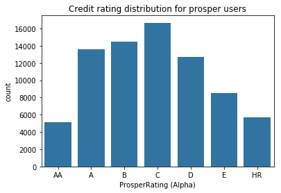

```python
# let's plot all three together to get an idea of each ordinal variable's distribution.
default_color = sns.color_palette()[0]
order_rating = ['AA','A','B','C','D','E','HR']
sns.countplot(data = prosper, x = "ProsperRating (Alpha)", color = default_color,order =order_rating )
plt.title("Credit rating distribution for prosper users")

plt.show()
```

#### Conclusion

> The above infers that most prosper users have a rating of between A and C.

#### Define: Distribution of "BorrowerState" counts.

#### Code

```python
#List of Top 10 states with the highest number of Prosper users
borrower_list = list(prosper.BorrowerState.value_counts().sort_values(ascending=False)[:10])
borrower_state = prosper.BorrowerState.value_counts().sort_values(ascending=False).index.tolist()[:10]
print(borrower_list,borrower_state)
```

```
[9633, 5224, 5115, 4787, 3889, 3086, 3025, 2542, 2474, 2440] ['CA', 'NY', 'TX', 'FL', 'IL', 'OH', 'GA', 'VA', 'NJ', 'PA']
```

```
Text(0.5,1,'Distribution of top 10 states with the most users')
```

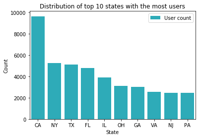

```python
#Visualize distribution
base_color = sns.color_palette()[9]
sns.barplot( x = borrower_state, y = borrower_list, color=base_color, label = 'User count')
plt.legend()
plt.xlabel('State')
plt.ylabel('Count')
plt.title("Distribution of top 10 states with the most users")
```

#### Conclusion

> Carlifornia has the highest number of prosper customers compared to other states

```python
prosper.head(10)
```

|  | ListingKey | ListingCreationDate | Term | LoanStatus | ClosedDate | BorrowerAPR | BorrowerRate | EstimatedLoss | EstimatedReturn | ProsperRating (numeric) | ProsperRating (Alpha) | ProsperScore | ListingCategory (numeric) | BorrowerState | Occupation | Occupation_group | EmploymentStatus | IsBorrowerHomeowner | CurrentlyInGroup | CreditScoreRangeLower | CreditScoreRangeUpper | FirstRecordedCreditLine | CurrentCreditLines | OpenCreditLines | TotalCreditLinespast7years | InquiriesLast6Months | TotalInquiries | CurrentDelinquencies | AmountDelinquent | … |
| --- | --- | --- | --- | --- | --- | --- | --- | --- | --- | --- | --- | --- | --- | --- | --- | --- | --- | --- | --- | --- | --- | --- | --- | --- | --- | --- | --- | --- | --- | --- |
| 1 | 10273602499503308B223C1 | 2014-02-27 08:28:07.900 | 36 | Current | 2022-10-19 23:45:11.428219 | 0.12016 | 0.0920 | 0.0249 | 0.05470 | 6.0 | A | 7.0 | 2 | CO | Professional | Professional | Employed | False | False | 680.0 | 699.0 | 1996-03-18 00:00:00 | 14.0 | 14.0 | 29.0 | 3.0 | 5.0 | 0.0 | 0.0 | … |
| 3 | 0EF5356002482715299901A | 2012-10-22 11:02:35.010 | 36 | Current | 2022-10-19 23:45:11.428219 | 0.12528 | 0.0974 | 0.0249 | 0.06000 | 6.0 | A | 9.0 | 16 | GA | Skilled Labor | skilled_labor | Employed | True | False | 800.0 | 819.0 | 1983-02-28 00:00:00 | 5.0 | 5.0 | 29.0 | 0.0 | 1.0 | 4.0 | 10056.0 | … |
| 4 | 0F023589499656230C5E3E2 | 2013-09-14 18:38:39.097 | 36 | Current | 2022-10-19 23:45:11.428219 | 0.24614 | 0.2085 | 0.0925 | 0.09066 | 3.0 | D | 4.0 | 2 | MN | Executive | Professional | Employed | True | False | 680.0 | 699.0 | 2004-02-20 00:00:00 | 19.0 | 19.0 | 49.0 | 1.0 | 9.0 | 0.0 | 0.0 | … |
| 5 | 0F05359734824199381F61D | 2013-12-14 08:26:37.093 | 60 | Current | 2022-10-19 23:45:11.428219 | 0.15425 | 0.1314 | 0.0449 | 0.07077 | 5.0 | B | 10.0 | 1 | NM | Professional | Professional | Employed | True | False | 740.0 | 759.0 | 1973-03-01 00:00:00 | 21.0 | 17.0 | 49.0 | 0.0 | 2.0 | 0.0 | 0.0 | … |
| 6 | 0F0A3576754255009D63151 | 2013-04-12 09:52:56.147 | 36 | Current | 2022-10-19 23:45:11.428219 | 0.31032 | 0.2712 | 0.1275 | 0.11070 | 2.0 | E | 2.0 | 1 | KS | Sales | Professional | Employed | False | False | 680.0 | 699.0 | 2000-09-29 00:00:00 | 10.0 | 7.0 | 20.0 | 0.0 | 0.0 | 0.0 | 0.0 | … |
| 7 | 0F1035772717087366F9EA7 | 2013-05-05 06:49:27.493 | 36 | Current | 2022-10-19 23:45:11.428219 | 0.23939 | 0.2019 | 0.0799 | 0.09840 | 4.0 | C | 4.0 | 2 | CA | Laborer | Other | Employed | False | False | 700.0 | 719.0 | 1999-02-25 00:00:00 | 6.0 | 6.0 | 10.0 | 3.0 | 16.0 | 0.0 | 0.0 | … |
| 8 | 0F043596202561788EA13D5 | 2013-12-02 10:43:39.117 | 36 | Current | 2022-10-19 23:45:11.428219 | 0.07620 | 0.0629 | 0.0099 | 0.04231 | 7.0 | AA | 9.0 | 7 | IL | Food Service | retail_mgt | Employed | True | False | 820.0 | 839.0 | 1993-04-01 00:00:00 | 17.0 | 16.0 | 32.0 | 1.0 | 6.0 | 0.0 | 0.0 | … |
| 10 | 0F123545674891886D9F106 | 2012-05-10 07:04:01.577 | 60 | Current | 2022-10-19 23:45:11.428219 | 0.27462 | 0.2489 | 0.0890 | 0.14420 | 4.0 | C | 7.0 | 1 | MD | Fireman | Civil_Service | Employed | False | False | 640.0 | 659.0 | 1989-11-29 00:00:00 | 2.0 | 2.0 | 56.0 | 1.0 | 2.0 | 1.0 | 253.0 | … |
| 12 | 0F1A3597143888805163EF7 | 2013-12-15 20:01:10.757 | 36 | Past Due (1-15 days) | 2022-10-19 23:45:11.428219 | 0.17969 | 0.1435 | 0.0524 | 0.07400 | 5.0 | B | 4.0 | 1 | AL | Sales | Professional | Employed | False | False | 680.0 | 699.0 | 1996-11-09 00:00:00 | 9.0 | 7.0 | 29.0 | 1.0 | 4.0 | 0.0 | 0.0 | … |
| 13 | 0F1C3583260311305D68F87 | 2013-07-15 16:28:28.087 | 36 | Current | 2022-10-19 23:45:11.428219 | 0.13138 | 0.1034 | 0.0274 | 0.06310 | 6.0 | A | 8.0 | 1 | AZ | Construction | Other | Employed | True | False | 740.0 | 759.0 | 2007-03-20 00:00:00 | 9.0 | 8.0 | 18.0 | 0.0 | 2.0 | 0.0 | 0.0 | … |

#### Define: Distribution of 'Terms' in the dataframe.

#### Code

```python
prosper.Term.value_counts()
```

```
36    52505
60    22849
12     1414
Name: Term, dtype: int64
```

```python
#Create a list
term_period = list(prosper.Term.value_counts().sort_values(ascending=False))
term_list = prosper.Term.value_counts().sort_values(ascending=False).index.tolist()
print(term_period,term_list)
```

```
[52505, 22849, 1414] [36, 60, 12]
```

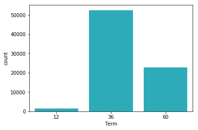

```python
#Visualise Term column
sns.countplot(data=prosper,x= 'Term',color=base_color);
```

```python
base_color = sns.color_palette()[0]
```

#### Conclusion

> Loans with a term of 36 months are the ost popular among prosper users.

#### Define: Distribution of 'Occupation_group' counts.

#### Code

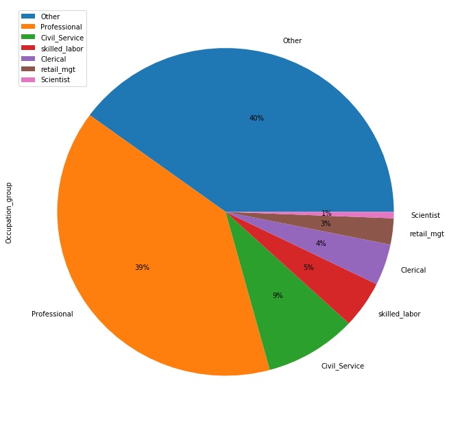

```python
#Visualize it
prosper['Occupation_group'].value_counts().plot(kind='pie',y = 'Occupation_group',figsize=(11, 11),legend=True,use_index=True,autopct='%1.0f%%');
```

#### Conclusion

> The top occupation groups are 'Others' and with 'Professional' coming in as second, followed by 'civil service'.

```python
prosper.sample(10)
```

|  | ListingKey | ListingCreationDate | Term | LoanStatus | ClosedDate | BorrowerAPR | BorrowerRate | EstimatedLoss | EstimatedReturn | ProsperRating (numeric) | ProsperRating (Alpha) | ProsperScore | ListingCategory (numeric) | BorrowerState | Occupation | Occupation_group | EmploymentStatus | IsBorrowerHomeowner | CurrentlyInGroup | CreditScoreRangeLower | CreditScoreRangeUpper | FirstRecordedCreditLine | CurrentCreditLines | OpenCreditLines | TotalCreditLinespast7years | InquiriesLast6Months | TotalInquiries | CurrentDelinquencies | AmountDelinquent | … |
| --- | --- | --- | --- | --- | --- | --- | --- | --- | --- | --- | --- | --- | --- | --- | --- | --- | --- | --- | --- | --- | --- | --- | --- | --- | --- | --- | --- | --- | --- | --- |
| 54857 | A475352888230108998B57C | 2011-10-06 11:11:16.417 | 36 | Current | 2022-10-19 23:45:11.428219 | 0.35643 | 0.3199 | 0.1470 | 0.14870 | 2.0 | E | 5.0 | 3 | NY | Engineer | Other | Employed | False | False | 720.0 | 739.0 | 2003-06-16 00:00:00 | 4.0 | 2.0 | 17.0 | 2.0 | 6.0 | 2.0 | 6857.0 | … |
| 101614 | 693836013073253671681B4 | 2014-01-30 13:21:38.087 | 60 | Current | 2022-10-19 23:45:11.428219 | 0.15844 | 0.1355 | 0.0474 | 0.07192 | 5.0 | B | 8.0 | 1 | GA | Executive | Professional | Employed | False | False | 700.0 | 719.0 | 1991-03-07 00:00:00 | 12.0 | 12.0 | 37.0 | 0.0 | 1.0 | 0.0 | 0.0 | … |
| 113551 | FB8035519887108739EBFDC | 2012-06-29 15:04:26.157 | 36 | Completed | 2012-09-14 00:00:00.000000 | 0.28851 | 0.2499 | 0.1190 | 0.11500 | 3.0 | D | 6.0 | 7 | CA | Other | Other | Other | False | False | 700.0 | 719.0 | 1990-12-15 00:00:00 | 2.0 | 2.0 | 6.0 | 0.0 | 6.0 | 0.0 | 0.0 | … |
| 38964 | 890B357596342348583F7EB | 2013-04-11 12:59:31.907 | 36 | Current | 2022-10-19 23:45:11.428219 | 0.09837 | 0.0849 | 0.0199 | 0.05320 | 7.0 | AA | 10.0 | 1 | MN | Engineer | Other | Employed | True | False | 760.0 | 779.0 | 1979-03-01 00:00:00 | 13.0 | 12.0 | 44.0 | 1.0 | 5.0 | 0.0 | 0.0 | … |
| 96961 | 545B354585845555341A456 | 2012-05-09 18:56:36.917 | 60 | Current | 2022-10-19 23:45:11.428219 | 0.13084 | 0.1085 | 0.0100 | 0.08840 | 7.0 | AA | 10.0 | 1 | MO | Food Service Management | retail_mgt | Employed | True | True | 780.0 | 799.0 | 1992-01-09 00:00:00 | 13.0 | 11.0 | 45.0 | 0.0 | 1.0 | 0.0 | 0.0 | … |
| 8733 | 9BF736034871521233A6665 | 2014-02-14 12:26:33.983 | 36 | Current | 2022-10-19 23:45:11.428219 | 0.13226 | 0.1039 | 0.0299 | 0.06081 | 6.0 | A | 7.0 | 1 | AZ | Other | Other | Employed | True | False | 680.0 | 699.0 | 1988-03-19 00:00:00 | 5.0 | 5.0 | 22.0 | 0.0 | 2.0 | 0.0 | 0.0 | … |
| 53407 | 6F813592775492214D0ED09 | 2013-10-13 13:23:45.717 | 36 | Current | 2022-10-19 23:45:11.428219 | 0.18020 | 0.1440 | 0.0474 | 0.08004 | 5.0 | B | 7.0 | 1 | GA | Engineer | Other | Employed | True | False | 700.0 | 719.0 | 1998-08-10 00:00:00 | 12.0 | 10.0 | 19.0 | 0.0 | 1.0 | 0.0 | 0.0 | … |
| 38211 | 9B5F3582449650117887113 | 2013-06-18 20:34:40.630 | 36 | Current | 2022-10-19 23:45:11.428219 | 0.08930 | 0.0759 | 0.0149 | 0.04980 | 7.0 | AA | 10.0 | 1 | WI | Skilled Labor | skilled_labor | Employed | True | False | 760.0 | 779.0 | 1994-08-01 00:00:00 | 9.0 | 8.0 | 18.0 | 1.0 | 5.0 | 0.0 | 0.0 | … |
| 26833 | 9A213566104621670021D83 | 2012-12-28 15:25:19.463 | 36 | Completed | 2013-04-25 00:00:00.000000 | 0.21025 | 0.1734 | 0.0624 | 0.09120 | 4.0 | C | 4.0 | 1 | CA | Truck Driver | skilled_labor | Employed | False | False | 780.0 | 799.0 | 1998-07-01 00:00:00 | 9.0 | 8.0 | 18.0 | 2.0 | 5.0 | 0.0 | 0.0 | … |
| 96984 | FA473562596160980C3B628 | 2012-11-01 11:57:04.010 | 36 | Completed | 2013-04-10 00:00:00.000000 | 0.12528 | 0.0974 | 0.0249 | 0.06000 | 6.0 | A | 8.0 | 6 | AZ | Fireman | Civil_Service | Employed | False | False | 780.0 | 799.0 | 1995-04-28 00:00:00 | 5.0 | 5.0 | 48.0 | 2.0 | 9.0 | 0.0 | 0.0 | … |